# 6,243 Introduction to Programming

Lecture 2: Getting Started

Dr. Franziska Bender, Dr. Aurélien Sallin

2025-09-16

## Goals for today

In this lecture, we will:

- understand what is **version control** to collaborate
- know basic in `git`
- install and prepare `git`

In the next lecture, we will

- create a github account
- collaborate on git

## Vision

Track your work. Collaborate on programming/data science projects.

## Prerequisites

- git: The tool itself
- VS Code with the git extension

# What is git?

## A daily situation…

[figure not shown]

## A daily situation…

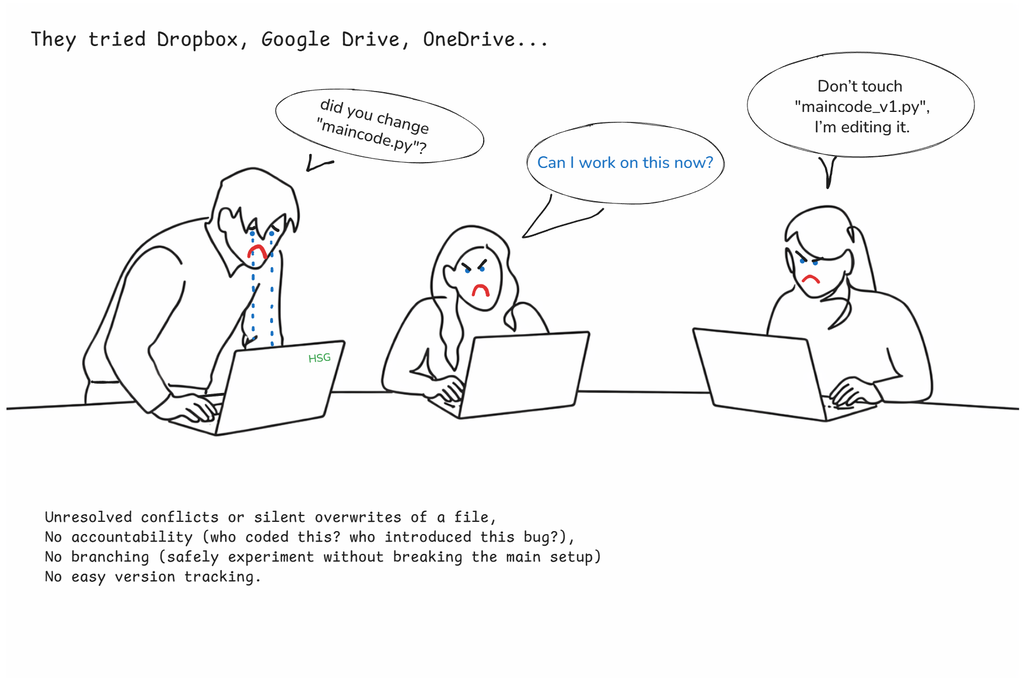

## A daily situation…

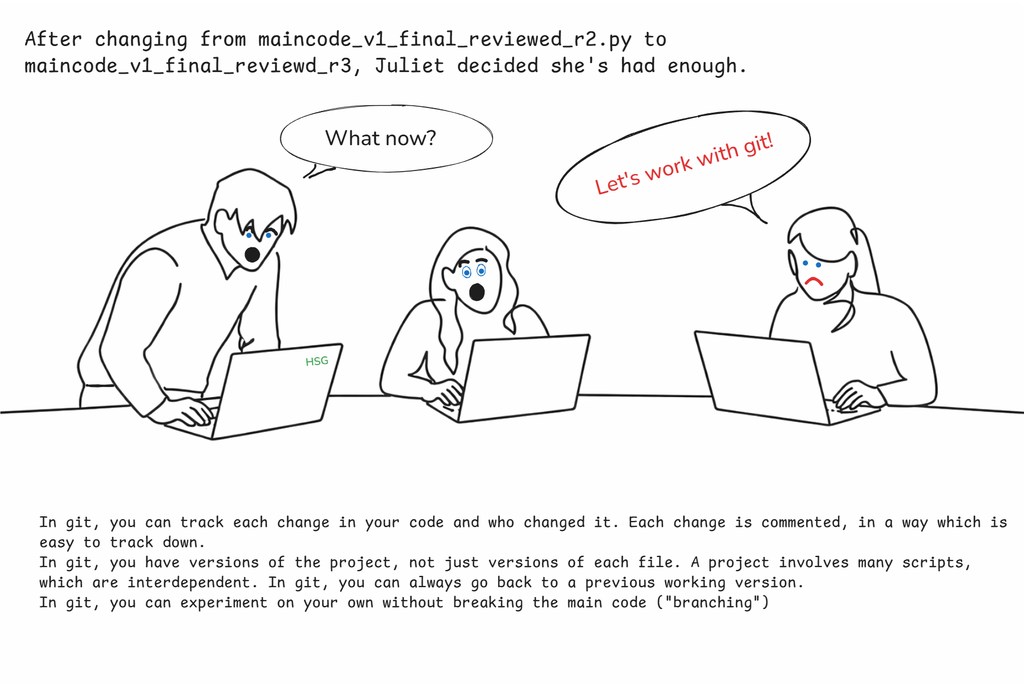

## A daily situation…

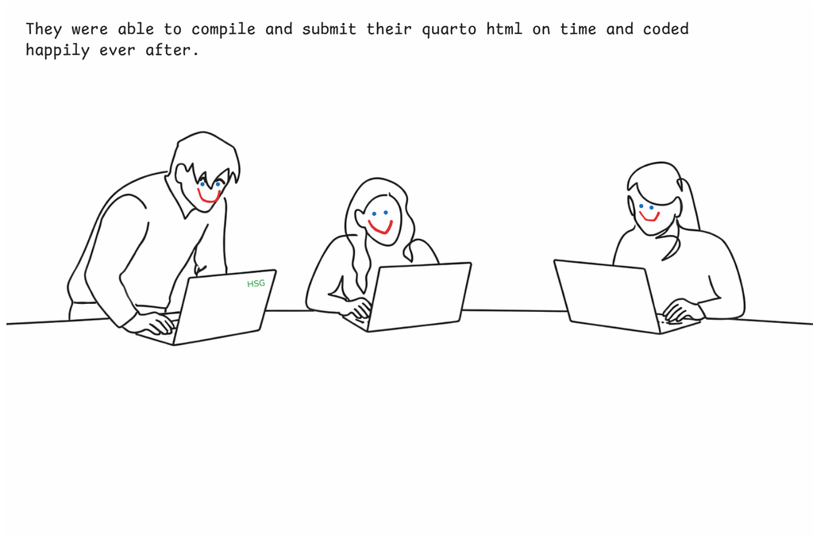

## What is git?

#### Version Control System (VCS)

- Looks at the changes in your files
- Records all changes over time to give you a full history
- Similar to “track changes” in Microsoft Word

#### Git only looks at and tracks the changes in a file

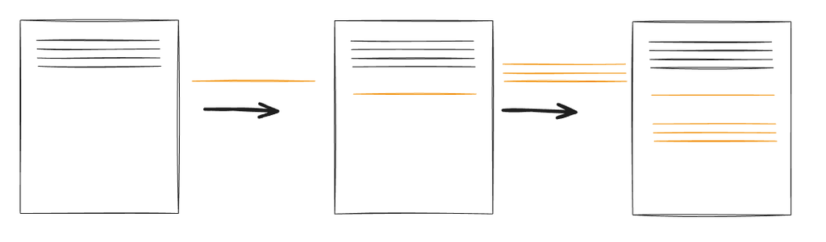

## Why should we learn git?

- Very hard to lose files with git
- Great for collaboration
- History allows you to go back and understand changes or revert when there are problems
- Reproducibility
- In demand for any data science job

## Git and the Command Line Interface (CLI)

#### Git is usually used from a CLI (like a terminal)

- Learn git commands and use them in a terminal.
- Very flexible, but a bit unintuitive

#### But also from Graphical User Interface (GUI)

- Most applications nowadays: GitHub Desktop, VSCode extension, RStudio
- Often easier to use and no commands needed.
- Easier to visualize the steps.

## In this course

We will learn the basic commands of git in a CLI, and we will use the GUI in VSCode

All the commands we will learn are available in the official [Git Cheat Sheet](https://education.github.com/git-cheat-sheet-education.pdf). Please download the sheet.

[figure not shown]

## Setting up git

##### From the cli:

- On windows, open Git Bash (start menu -> Git Bash). Make sure you’ve installed git beforehand.
- On MacOS, open the Terminal app.
- On Linux, open your distribution’s (or any other) terminal emulator.
- Let’s do this together now!

## Setting up git

Run the following commands in your terminal to correctly configure git on your computer.

```bash
# Add your name
git config --global user.name "Your Name"

# Add your email address
git config --global user.email "your.email@unisg.ch"

# Use modern main branch name
git config --global init.defaultbranch main
```

#### A detail (you only need to do this once at config, not to remember for the course):

```bash
# For Linux/Mac:
git config --global core.autocrlf input

# For Windows:
git config --global core.autocrlf true
```

Why? Windows saves linebreaks (enter) differently then Linux/Mac does. Remember Data Handling (Linux / macOS: LF `\n`, Windows: CRLF `\r\n`). Git may interpret this as code changes. This setting prevents unnecessary diffs and conflicts.

# Let’s start

## Initialize a git repository

A project in git is called a **repository** (or **repo** for short) and it always corresponds to a directory on your machine. This is usually where you save your project.

Remember our folder structure:

```
BECON_6243_Introduction_programming/
├── materials/              # is empty for now, you will clone the git repo in week 3
├── exercises/              # Student's own work
│   ├── week01/
│   ├── week02/
│   ├── ...
│   ├── week12/
├── group_project/
│   ├── ...
```

We will **initialize a repo** in the exercises folder. You will have to initialize another repo in your group_project folder.

## Initialize a repo

This is done via the `init` command.

In your terminal from VSCode, navigate to your cd BECON_6243_Introduction_programming/exercises. Then:

```bash
git init
# Initialized empty Git repository in /Users/BECON_6243_Introduction_programming/exercises
```

With git init we turn the directory into a repository.

At this point, 🗂️ **tracking has started!**

## See what’s happening: `git status`

To see the current status of a git repository you can run the status command.

```bash
git status
# On branch main
# No commits yet
# nothing to commit (create/copy files and use "git add" to track)
```

## Process in git: edit, select, commit

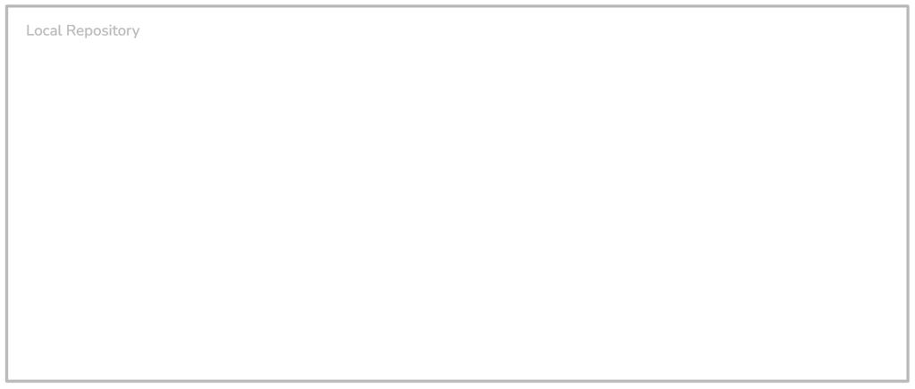

- The local repository is everything on your own computer.
- Nothing here is shared with others yet.
- Git always works locally first.

## Process in git: edit, select, commit

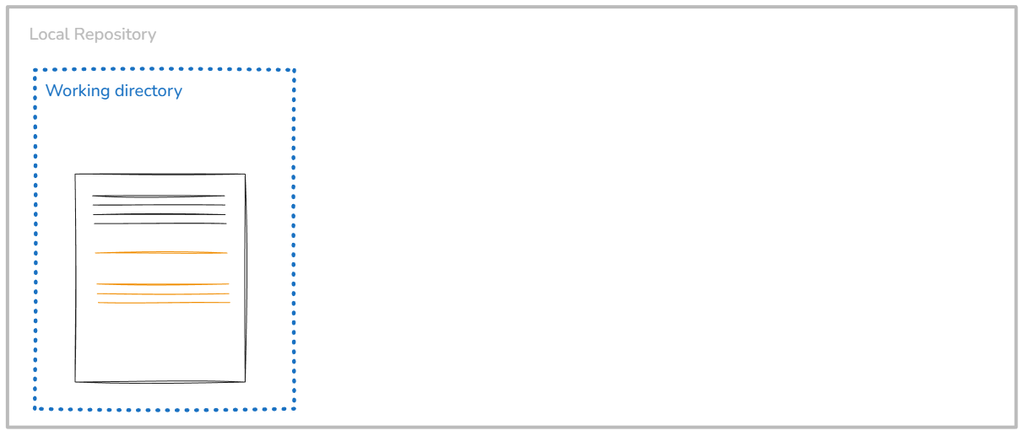

- The working directory is where you write code, edit files, run scripts, etc.
- Files here may be untracked, modified or unfinished
- Saving a file only affects the working directory. Git does nothing yet.

## Process in git: edit, select, commit

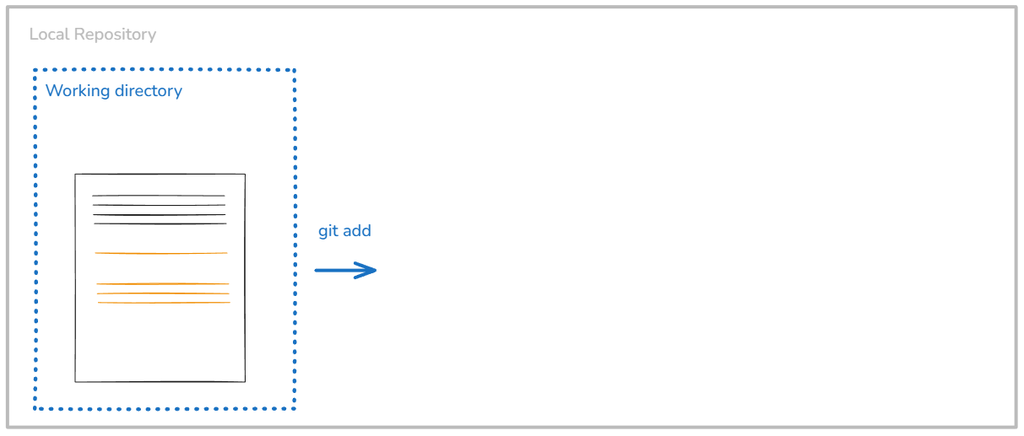

- Use `git add` to select your files in the staging area.
- The staging area is a selection step.
- Here, you decide which files or which changes will be part of the next commit.

## Process in git: edit, select, commit

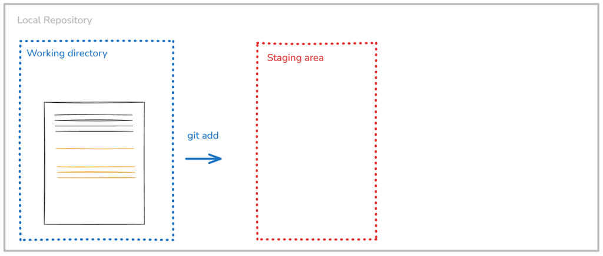

- The staging area is a **list of changes** you are about to record.
- It is not a folder and not a backup.
- You can stage edits that logically belong together.

## Process in git: edit, select, commit

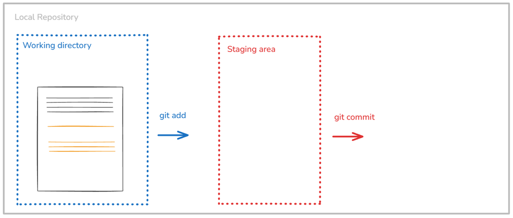

- Use `git commit` to record the staged changes and creates a snapshot in time.
- It adds a message explaining why the change was made.
- ! Commits are: permanent, ordered, traceable, attributable to a person